# Red Wine Exploration by Zhang Guanghui

### Investigate whether other features strengthen volatile.acidity or not

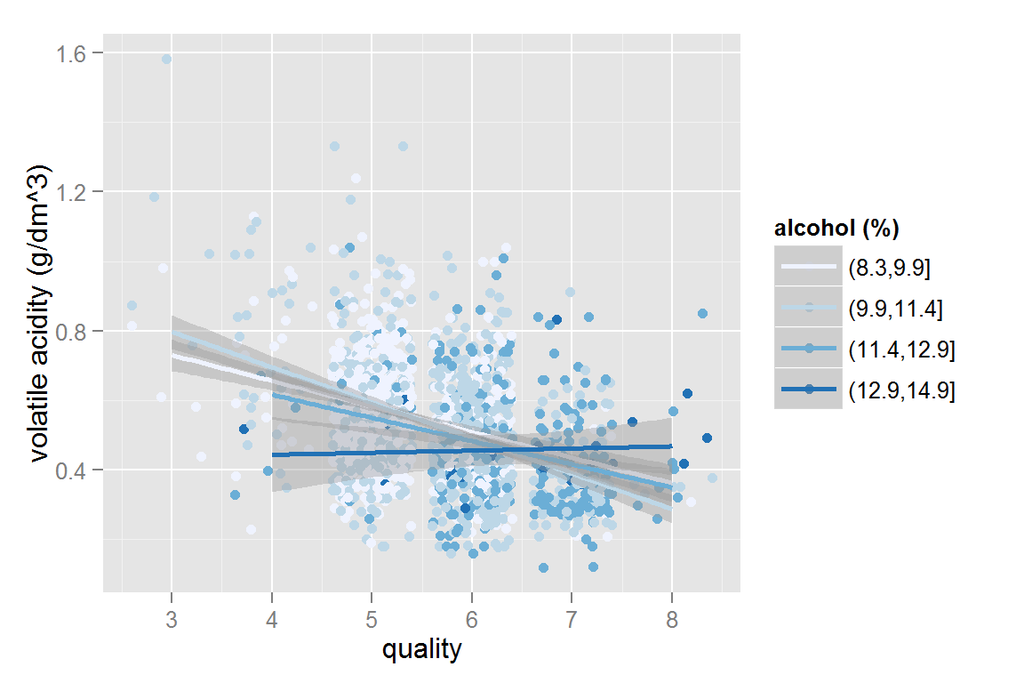

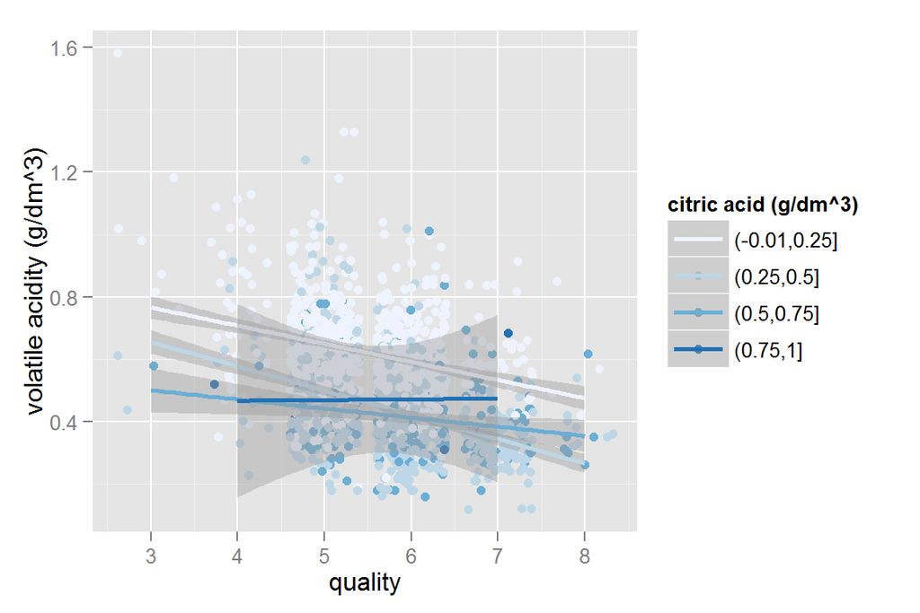

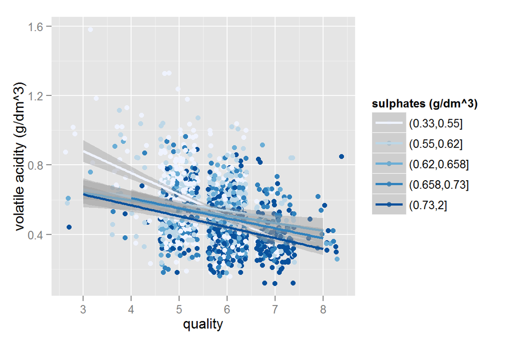

— The plot shows that low-quality red wine tends to have high volatile acidity, but for red wine with citric acid from 0.75 to 1.0, the affect is insignificant.

### Investigate whether other features strengthen sulphates or not

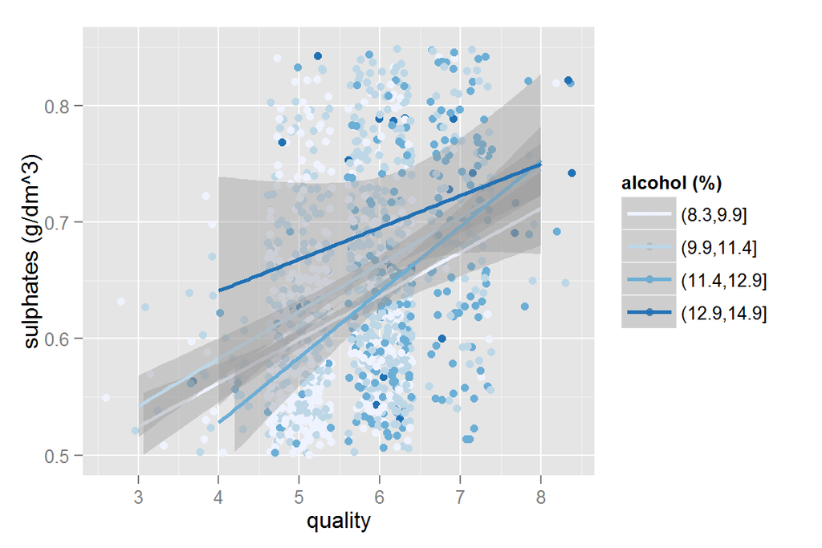

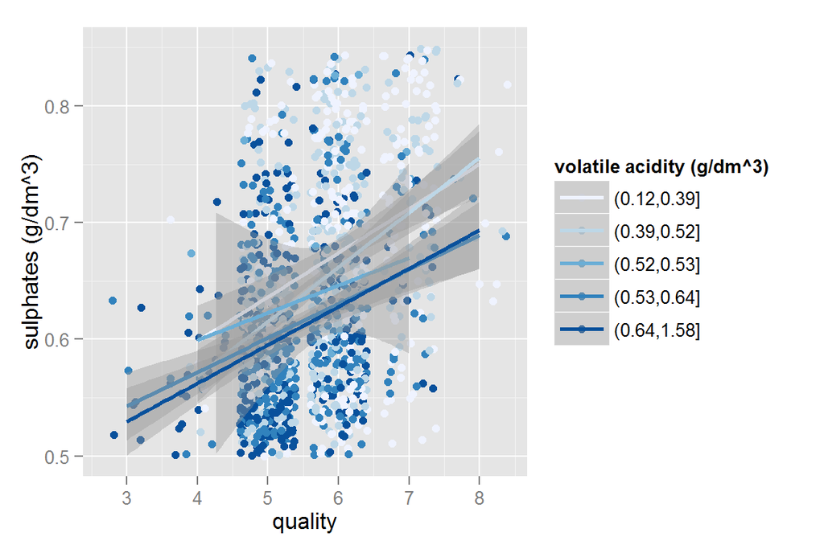

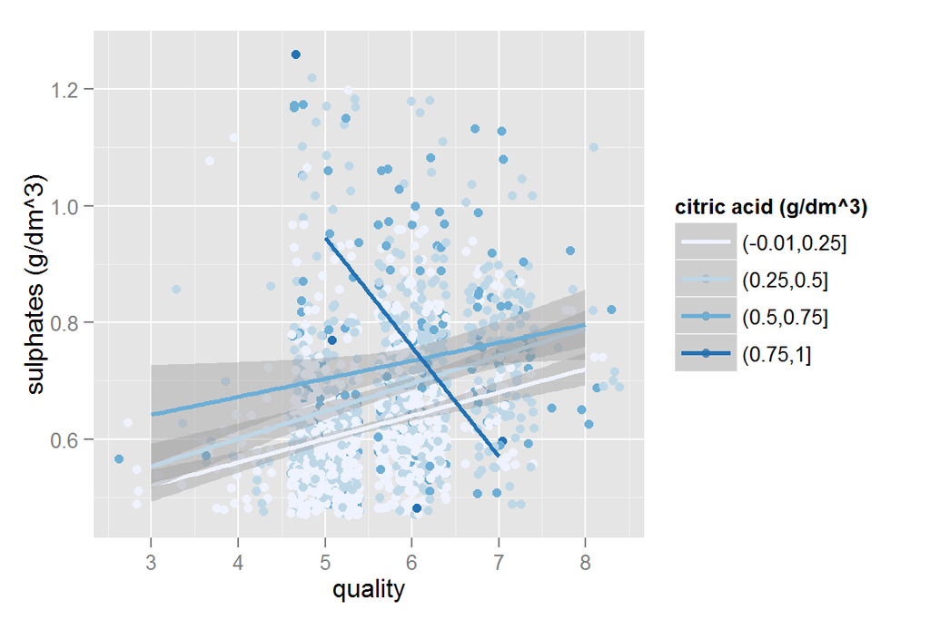

### Establish a relationship between features

```
Call:
lm(formula = redwine$quality ~ redwine$alcohol + redwine$volatile.acidity +
    redwine$citric.acid + redwine$sulphates)

Coefficients:
             (Intercept)           redwine$alcohol  redwine$volatile.acidity       redwine$citric.acid
                 2.64592                   0.30908                  -1.26506                  -0.07913
       redwine$sulphates
                 0.69552
```

— Linear regression analysis skills are used to set up a relationship between quality and other relevent variables. In the regression model, intercept is 2.65, the coefficient for alcohol, volatile acidity, citric acid, sulphates are 0.309, -1.265, -0.079, 0.6955

# Multivariate Analysis

### Talk about some of the relationships you observed in this part of the investigation. Were there features that strengthened each other in terms of looking at your feature(s) of interest?

— 1. In the vestigation it is found out that high alcohol will contribute to high quality. High sulphate wil generally makes the effect of alcohol more obvious.

— 2. Volatile.acidity negatively affect the quality of red wine. High votalie acid would usually make low qulatity. When colord by citric acid, alcohol, sulphate, The effect is quite positive when volatile acidity is low, but become trivial when volatile is high.

### Were there any interesting or surprising interactions between features?

— It is quite interesting, even though alcohol, volatile acidity, citric acid, sulphates contribute to quality, they not all work positively.

### Did you create any models with your dataset? Discuss the strengths and limitations of your model.

— I established a linear model to predict the quality based on the strong related features. I could give a quality score with the input of alcohol, sulphates, volatile acidity, sulphates. However, the quality of red wine is the combined evaluation of color, flavour, taste, etc. The content of chemicals is indirectly related to these physical characterstic of the red wine.Besides, in the proposed model, the features are numeric variables and predicted quality is also numeric. The model needs to be revised so it can predict quality in more accurate manner.

# Final Plots and Summary

### Plot One

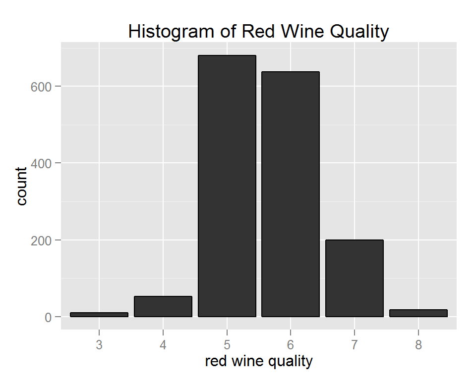

### Description One

— The histogram shows that the major of red wine has quality 5 or 6. Few red wines have very high or very low quality score. I continue the exploration by investigate which features are strongly related to quality.

### Plot Two

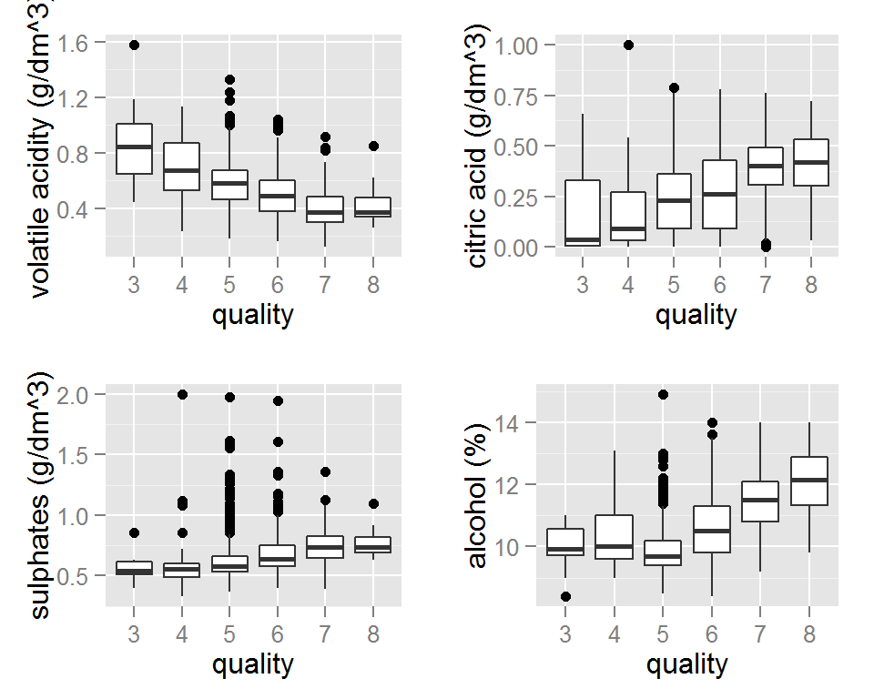

### Description Two

— The plot shows the boxplot of four major features against quality. It has been observed that volative acidity negatively contributes to quality, on the other hand citric acid, sulphates, and alcohol are positively related to quality. The strong correlation cofficient is found between quality and alcohol. The plots indicate that high quality red wine has obvious higher alcohol.

### Plot Three

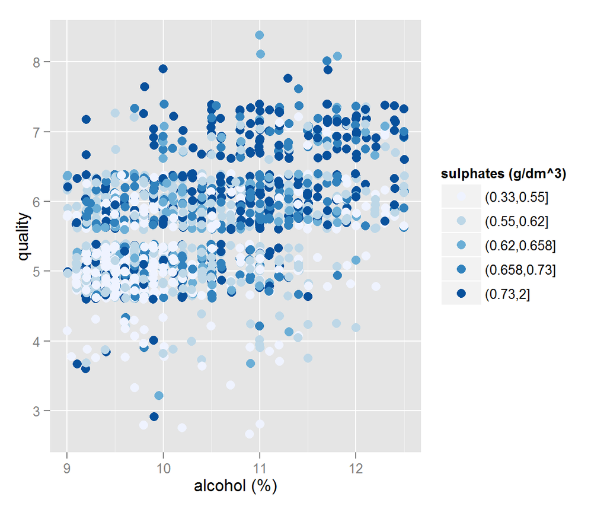

### Description Three

— A Very strong relationship has been observed between quality and alcohol. The plot also indicates the content of sulphates strengthen the effect of alcohol. Since quality of red wine is a combined evaluation of many different characteristic of the wine, a linear regression model is established to predict quality using four strongly-related features.

### Reflection

— This dataset contains 1599 kinds of red wine. Each wine has 12 features. Firstly, I investigated each individual feature by ploting histograms. As I make each plot, I observe the characterstic of each distribution. Afterwards, I explored the quality of red wine across other features and study which features determine the quality. It is discovered that quality is strongly correlated with alcohol, volatile acidity, citric acid, sulphates. A linear regression model is created to predict quality. According to analysis, density and ph value play insignificant role in quality. It is out of my expecation that residual sugar does not quite contribute to high quaity. It is also surprised that quality is negatively related to volatile acidity, but not quite related to fixed acidity. Another interesting finding is that even though sulphates, fixed sulfur dioxide, and total sulfur dioxide has element sulfur, but only sulphates is clearly related to high quality. The limitation of the linear regression model must be noted. Firstly, most of the features of red wine is related to the content of chemicals. The quality of red wine is the combined evaluation of color, flavour, taste, etc. The content of chemicals is indirectly related to these physical characterstic of the red wine. Secondly, the quality of red wine is rated by experts with score from 0 to 10. In the dataset, about eighty percent of the redwines is rated with score 5 and 6, and very few has lower score and higher score. The quality is too clustered. The linear regression model will be more valid if the dataset could involve more red wines with bad and high quality. Thirdly, the quality of red wine is ordered factor with 10 levels. In the proposed model, the features are numeric variables and predicted quality is also numeric. The model needs to be revised so it can predict ordered factor.